# Bank Credit Approval

The project involves several key activities. First, the dataset for credit approval is loaded, and a visual inspection is conducted to understand the distribution of credit approval based on each attribute, identifying variables crucial for data separation. Next, the dataset is prepared, and missing values are imputed using the missForest library. The dataset is then divided into training and test sets. Subsequently, Ridge and Lasso regularized logistic regression models are trained on the training set, with the goal of selecting the model with the best AUC, and metrics are calculated on the test set. The project also aims to reveal the factor by which predictor variables influence the odds ratio when increased by one unit. Finally, the profitability of applying the model is assessed based on gaining 100e for every true positive and losing 20e for every false positive.

We will take the dataset for bank credit approval from https://archive.ics.uci.edu/ml/datasets/Credit+Approval.

Number of Instances: 690

Number of Attributes: 15 + class attribute

Attribute Information: A1: b, a. A2: continuous. A3: continuous. A4: u, y, l, t. A5: g, p, gg. A6: c, d, cc, i, j, k, m, r, q, w, x, e, aa, ff. A7: v, h, bb, j, n, z, dd, ff, o. A8: continuous. A9: t, f. A10: t, f. A11: continuous. A12: t, f. A13: g, p, s. A14: continuous. A15: continuous. A16: +,- (class attribute)

Missing Attribute Values: In 37 cases (5%), one or more values are missing. The missing values for specific attributes are: A1: 12 A2: 12 A4: 6 A5: 6 A6: 9 A7: 9 A14: 13

Class Distribution: +: 307 (44.5%) -: 383 (55.5%)

```r
data <- read.csv("crx.data", header=FALSE, na.strings = "?" )
str(data)
```

```
'data.frame':   690 obs. of  16 variables:
 $ V1 : chr  "b" "a" "a" "b" ...
 $ V2 : num  30.8 58.7 24.5 27.8 20.2 ...
 $ V3 : num  0 4.46 0.5 1.54 5.62 ...
 $ V4 : chr  "u" "u" "u" "u" ...
 $ V5 : chr  "g" "g" "g" "g" ...
 $ V6 : chr  "w" "q" "q" "w" ...
 $ V7 : chr  "v" "h" "h" "v" ...
 $ V8 : num  1.25 3.04 1.5 3.75 1.71 ...
 $ V9 : chr  "t" "t" "t" "t" ...
 $ V10: chr  "t" "t" "f" "t" ...
 $ V11: int  1 6 0 5 0 0 0 0 0 0 ...
 $ V12: chr  "f" "f" "f" "t" ...
 $ V13: chr  "g" "g" "g" "g" ...
 $ V14: int  202 43 280 100 120 360 164 80 180 52 ...
 $ V15: int  0 560 824 3 0 0 31285 1349 314 1442 ...
 $ V16: chr  "+" "+" "+" "+" ...
```

```r
dim(data)
```

```
[1] 690  16
```

```r
head(data)
```

|  | V1 | V2 | V3 | V4 | V5 | V6 | V7 | V8 | V9 | V10 | V11 | V12 | V13 | V14 | V15 | V16 |
| --- | --- | --- | --- | --- | --- | --- | --- | --- | --- | --- | --- | --- | --- | --- | --- | --- |
| 1 | b | 30.83 | 0.000 | u | g | w | v | 1.25 | t | t | 1 | f | g | 202 | 0 | + |
| 2 | a | 58.67 | 4.460 | u | g | q | h | 3.04 | t | t | 6 | f | g | 43 | 560 | + |
| 3 | a | 24.50 | 0.500 | u | g | q | h | 1.50 | t | f | 0 | f | g | 280 | 824 | + |
| 4 | b | 27.83 | 1.540 | u | g | w | v | 3.75 | t | t | 5 | t | g | 100 | 3 | + |
| 5 | b | 20.17 | 5.625 | u | g | w | v | 1.71 | t | f | 0 | f | s | 120 | 0 | + |
| 6 | b | 32.08 | 4.000 | u | g | m | v | 2.50 | t | f | 0 | t | g | 360 | 0 | + |

```r
summary(data)
```

```
      V1                  V2              V3              V4                 V5                 V6                 V7
 Length:690         Min.   :13.75   Min.   : 0.000   Length:690         Length:690         Length:690         Length:690
 Class :character   1st Qu.:22.60   1st Qu.: 1.000   Class :character   Class :character   Class :character   Class :character
 Mode  :character   Median :28.46   Median : 2.750   Mode  :character   Mode  :character   Mode  :character   Mode  :character
                    Mean   :31.57   Mean   : 4.759
                    3rd Qu.:38.23   3rd Qu.: 7.207
                    Max.   :80.25   Max.   :28.000
                    NA's   :12
       V8              V9                V10                 V11           V12                V13                 V14
 Min.   : 0.000   Length:690         Length:690         Min.   : 0.0   Length:690         Length:690         Min.   :   0
 1st Qu.: 0.165   Class :character   Class :character   1st Qu.: 0.0   Class :character   Class :character   1st Qu.:  75
 Median : 1.000   Mode  :character   Mode  :character   Median : 0.0   Mode  :character   Mode  :character   Median : 160
 Mean   : 2.223                                         Mean   : 2.4                                         Mean   : 184
 3rd Qu.: 2.625                                         3rd Qu.: 3.0                                         3rd Qu.: 276
 Max.   :28.500                                         Max.   :67.0                                         Max.   :2000
                                                                                                             NA's   :13
      V15               V16
 Min.   :     0.0   Length:690
 1st Qu.:     0.0   Class :character
 Median :     5.0   Mode  :character
 Mean   :  1017.4
 3rd Qu.:   395.5
 Max.   :100000.0
```

We format the variables properly. We observe that V15 undergoes a significant imbalance due to a few extremely high values. We detect outliers using the interquartile range. Additionally, we convert all categorical variables into factors.

```r
data$V1 <- as.factor(data$V1)

data$V4 <- as.factor(data$V4)

data$V5 <- as.factor(data$V5)

data$V6 <- as.factor(data$V6)

data$V7 <- as.factor(data$V7)

data$V9 <- as.factor(data$V9)

data$V10 <- as.factor(data$V10)

data$V12 <- as.factor(data$V12)

data$V13 <- as.factor(data$V13)

data$V15 <- replace(data$V15, data$V15 >= 395 + 1.5*(395.5-0), 395 + 1.5*(395.5-0))

data$V16 <- replace(data$V16, data$V16 == "+", 1)
data$V16 <- replace(data$V16, data$V16 == "-", 0)
data$V16 <- as.factor(data$V16)

summary(data)
```

```
    V1            V2              V3            V4         V5            V6            V7            V8         V9      V10
 a   :210   Min.   :13.75   Min.   : 0.000   l   :  2   g   :519   c      :137   v      :399   Min.   : 0.000   f:329   f:395
 b   :468   1st Qu.:22.60   1st Qu.: 1.000   u   :519   gg  :  2   q      : 78   h      :138   1st Qu.: 0.165   t:361   t:295
 NA's: 12   Median :28.46   Median : 2.750   y   :163   p   :163   w      : 64   bb     : 59   Median : 1.000
            Mean   :31.57   Mean   : 4.759   NA's:  6   NA's:  6   i      : 59   ff     : 57   Mean   : 2.223
            3rd Qu.:38.23   3rd Qu.: 7.207                         aa     : 54   j      :  8   3rd Qu.: 2.625
            Max.   :80.25   Max.   :28.000                         (Other):289   (Other): 20   Max.   :28.500
            NA's   :12                                             NA's   :  9   NA's   :  9
      V11       V12     V13          V14            V15        V16
 Min.   : 0.0   f:374   g:625   Min.   :   0   Min.   :  0.0   0:383
 1st Qu.: 0.0   t:316   p:  8   1st Qu.:  75   1st Qu.:  0.0   1:307
 Median : 0.0           s: 57   Median : 160   Median :  5.0
 Mean   : 2.4                   Mean   : 184   Mean   :246.3
 3rd Qu.: 3.0                   3rd Qu.: 276   3rd Qu.:395.5
 Max.   :67.0                   Max.   :2000   Max.   :988.2
                                NA's   :13
```

We begin by plotting histograms for the continuous variables, separated by colors according to the target variable.

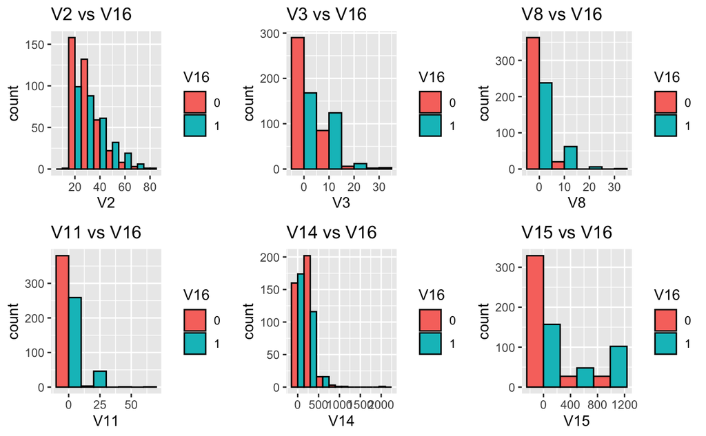

Now with discrete variables:

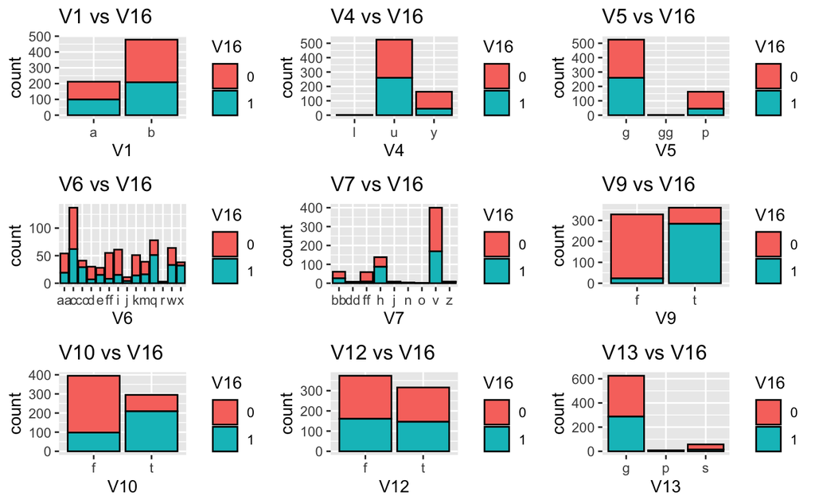

Next, we count missing values.

```r
sapply(data, function(x) sum(is.na(x)))
```

```
 V1  V2  V3  V4  V5  V6  V7  V8  V9 V10 V11 V12 V13 V14 V15 V16
 12  12   0   6   6   9   9   0   0   0   0   0   0  13   0   0
```

The dataset should be preprocessed to ensure it is in a suitable format for analysis, and any missing values present in the data should be filled in using the missForest library. We use missForest library to provide functions for imputing missing values in datasets, enabling us to address incomplete data before proceeding with further analysis or modeling tasks.

```r
sapply(data, function(x) sum(is.na(x)))
```

```
 V1  V2  V3  V4  V5  V6  V7  V8  V9 V10 V11 V12 V13 V14 V15 V16
  0   0   0   0   0   0   0   0   0   0   0   0   0   0   0   0
```

Now, we perform a One Hot Encoding (OHE) on the categorical variables.

```r
head(dataOHE)
```

```
  V1a V1b    V2    V3 V4u V4y V5gg V5p V6c V6cc V6d V6e V6ff V6i V6j V6k V6m V6q V6r V6w V6x V7dd V7ff V7h V7j V7n V7o V7v V7z   V8
1   0   1 30.83 0.000   1   0    0   0   0    0   0   0    0   0   0   0   0   0   0   1   0    0    0   0   0   0   0   1   0 1.25
2   1   0 58.67 4.460   1   0    0   0   0    0   0   0    0   0   0   0   0   1   0   0   0    0    0   1   0   0   0   0   0 3.04
3   1   0 24.50 0.500   1   0    0   0   0    0   0   0    0   0   0   0   0   1   0   0   0    0    0   1   0   0   0   0   0 1.50
4   0   1 27.83 1.540   1   0    0   0   0    0   0   0    0   0   0   0   0   0   0   1   0    0    0   0   0   0   0   1   0 3.75
5   0   1 20.17 5.625   1   0    0   0   0    0   0   0    0   0   0   0   0   0   0   1   0    0    0   0   0   0   0   1   0 1.71
6   0   1 32.08 4.000   1   0    0   0   0    0   0   0    0   0   0   0   1   0   0   0   0    0    0   0   0   0   0   1   0 2.50
  V9t V10t V11 V12t V13p V13s V14 V15
1   1    1   1    0    0    0 202   0
2   1    1   6    0    0    0  43 560
3   1    0   0    0    0    0 280 824
4   1    1   5    1    0    0 100   3
5   1    0   0    0    0    1 120   0
6   1    0   0    1    0    0 360   0
```

We are going to divide the dataset: 590 elements as train and 100 as test.

```r
dim(train)
```

```
[1] 590  38
```

```r
dim(test)
```

```
[1] 100  38
```

```r
table(data[1:590,]$V16)
```

```
  0   1
297 293
```

```r
table(data[591:nrow(data), ]$V16)
```

```
 0  1
86 14
```

Now, a logistic regression model with Ridge and Lasso regularization is trained on the training data, selecting the one with the best Area Under the Curve (AUC). This involves creating a separation between the features (X_train) and the target variable (y_train) for training purposes, and also creating a separate set for testing, with features (X_test) and corresponding target variable (y_test). The performance of both Ridge and Lasso models is then evaluated using AUC, and the model with the highest AUC on the training data is chosen. Finally, the selected model’s metrics, such as accuracy, precision, recall, and F1-score, are calculated on the test data to assess its performance on unseen data.

First, we apply Ridge regularization:

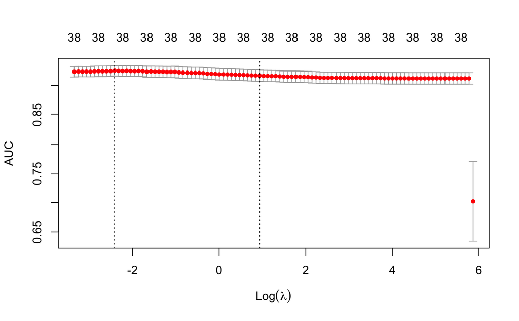

```r
cv.ridge$lambda.min
```

```
[1] 0.08939105
```

```r
max(cv.ridge$cvm)
```

```
[1] 0.9250539
```

We can observe that the model regularized by Ridge with $\lambda$ has an AUC of 0.925. We´ll see now the Lasso regularization:

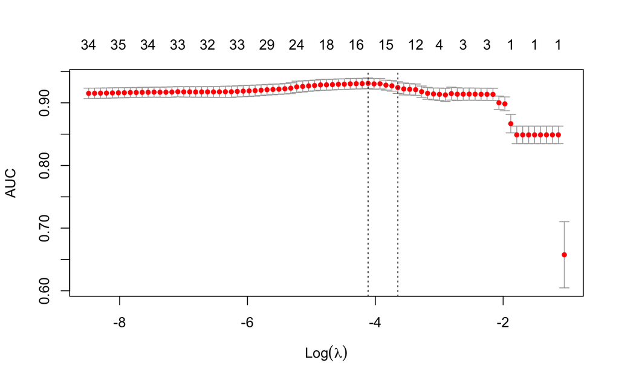

```r
cv.lasso$lambda.min
```

```
[1] 0.01636516
```

```r
max(cv.lasso$cvm)
```

```
[1] 0.9311887
```

We observe that the regularized Lasso model with optimal λ has an AUC of 0.931. Since the AUC of the Lasso model is greater than that of Ridge, we choose the model obtained through Lasso regularization. Let’s examine the coefficients of the optimal model obtained through Lasso regularization.

```r
coef(cv.lasso, s=cv.lasso$lambda.min)
```

```
39 x 1 sparse Matrix of class "dgCMatrix"
                       s1
(Intercept) -2.6365127231
V1a          .
V1b          .
V2           .
V3           .
V4u          .
V4y         -0.3577884260
V5gg         2.3136498809
V5p          .
V6c          .
V6cc         0.6282373395
V6d          .
V6e          .
V6ff        -0.4957750405
V6i          .
V6j          .
V6k         -0.1488210710
V6m          .
V6q          .
V6r          .
V6w          .
V6x          0.9810298390
V7dd         .
V7ff         .
V7h          0.2794352493
V7j          .
V7n          1.3706456480
V7o          .
V7v          .
V7z          .
V8           0.0294461678
V9t          3.0138219664
V10t         0.6853139455
V11          0.0380620099
V12t         .
V13p         1.6818545028
V13s         .
V14         -0.0008153804
V15          0.0012576135
```

We calculate the prediction on the test data and its metrics. We display the first six predictions along with their corresponding actual values.

```r
head(y_pred)
```

```
[1] 1 1 0 0 0 0
Levels: 0 1
```

```r
head(y_test)
```

```
[1] 1 1 1 1 1 1
Levels: 0 1
```

We provide metrics on the test.

```r
confusionMatrix(y_test, y_pred, mode="everything")
```

```
Confusion Matrix and Statistics

          Reference
Prediction  0  1
         0 85  1
         1  8  6

               Accuracy : 0.91
                 95% CI : (0.836, 0.958)
    No Information Rate : 0.93
    P-Value [Acc > NIR] : 0.8380

                  Kappa : 0.5273

 Mcnemar's Test P-Value : 0.0455

            Sensitivity : 0.9140
            Specificity : 0.8571
         Pos Pred Value : 0.9884
         Neg Pred Value : 0.4286
              Precision : 0.9884
                 Recall : 0.9140
                     F1 : 0.9497
             Prevalence : 0.9300
         Detection Rate : 0.8500
   Detection Prevalence : 0.8600
      Balanced Accuracy : 0.8856

       'Positive' Class : 0
```

We observe that the model exhibits a high accuracy of 91% and a precision of 98.84%

Let’s remember that the impact a coefficient βᵢ has on the odds ratio is that, for each unit increase in the corresponding predictor variable, the odds ratio will be multiplied by $e^{βᵢ}$.

```r
exp(coef(cv.lasso, s=cv.lasso$lambda.min))
```

```
39 x 1 Matrix of class "dgeMatrix"
                     s1
(Intercept)  0.07161056
V1a          1.00000000
V1b          1.00000000
V2           1.00000000
V3           1.00000000
V4u          1.00000000
V4y          0.69922100
V5gg        10.11126229
V5p          1.00000000
V6c          1.00000000
V6cc         1.87430390
V6d          1.00000000
V6e          1.00000000
V6ff         0.60909865
V6i          1.00000000
V6j          1.00000000
V6k          0.86172329
V6m          1.00000000
V6q          1.00000000
V6r          1.00000000
V6w          1.00000000
V6x          2.66720162
V7dd         1.00000000
V7ff         1.00000000
V7h          1.32238278
V7j          1.00000000
V7n          3.93789237
V7o          1.00000000
V7v          1.00000000
V7z          1.00000000
V8           1.02988399
V9t         20.36508605
V10t         1.98439473
V11          1.03879565
V12t         1.00000000
V13p         5.37551564
V13s         1.00000000
V14          0.99918495
V15          1.00125840
```

We observe that variable V6ff is the most detrimental to credit approval, while variable V9t is the most favorable to such approval.